# Analyse de Données

```r
source(file = "ProjetBis.R")
```

## Analyse de données

### Nuage de mots des compétences les plus demandées pondérées par le nombre de brevets

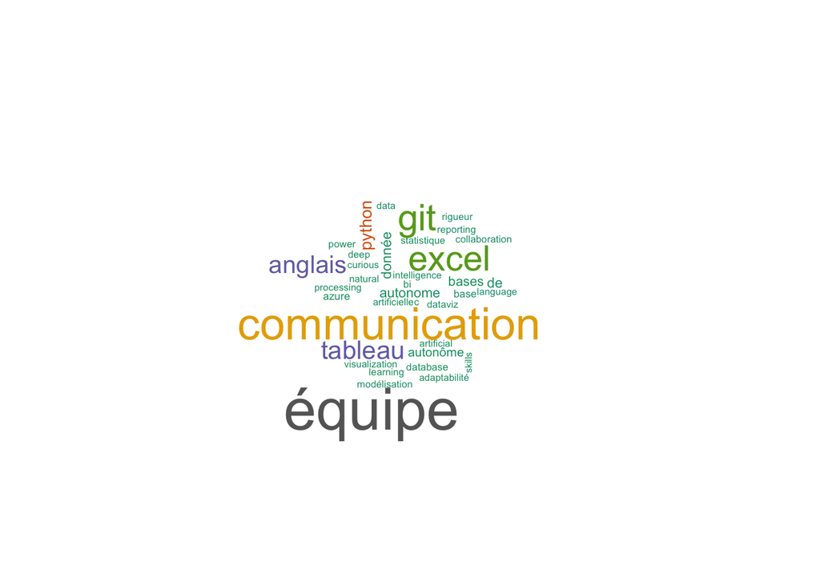

Le nuage de mots met en évidence un besoin important pour différentes compétences. Des compétences techniques liées à la data science et à l’informatique telles que Python, Git, Excel. Des compétences interpersonnelles et linguistiques telles que le travail en équipe (“équipe”), la communication, l’anglais. Ainsi que des cimpétences comportementales comme l’autonomie et l’adaptabilité.  
Cela traduit probablement une forte demande pour des professionnels polyvalents, capables de travailler en équipe tout en possédant des compétences analytiques et techniques.

### Top 10 des compétences associées à l’innovation

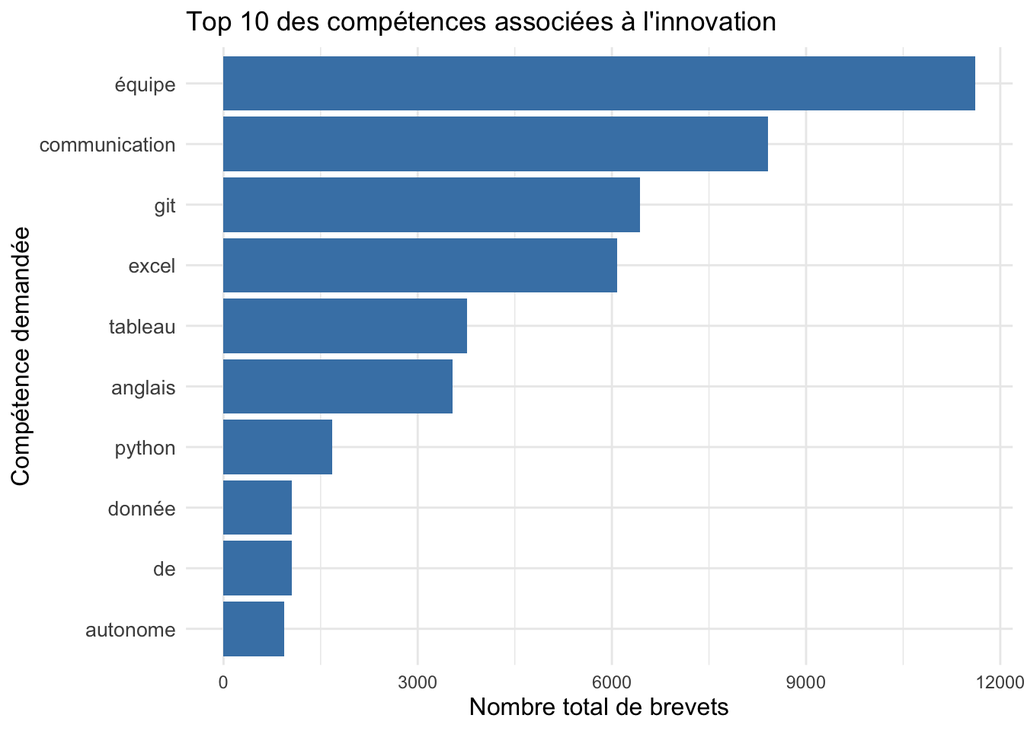

On remarque que les compétences “équipe”, “communication”, “git”, “excel”, “anglais”, “python” apparaissent dans les deux graphiques (le précédent et ce dernier). Cela nous confirme que ces compétences sont non seulement fréquemment demandées mais aussi fortement liées à l’innovation. L’importance de “git”, “excel”, et “tableau” montre que les compétences techniques associées à la gestion de versions, l’analyse de données, et la visualisation jouent un rôle crucial. La communication et le travail en équipe dominent dans les deux graphiques, soulignant un équilibre entre compétences techniques et interpersonnelles.

[figure not shown]

Ce graphique nous montre dans l’ordre décroissant que les principaux domaines techniques de l’innovation sont :- La pharmacie et la santé (A61K).  
- Les semi-conducteurs et les télécommunications (H01L, H04W).  
- L’automobile et les technologies embarquées (B60C, B60W).  
- Les capteurs et la mesure (G01S).

Cette analyse ouvre les portes à l’analyse de la répartition sectorielle des brevets.

### Nombre de brevets par secteur

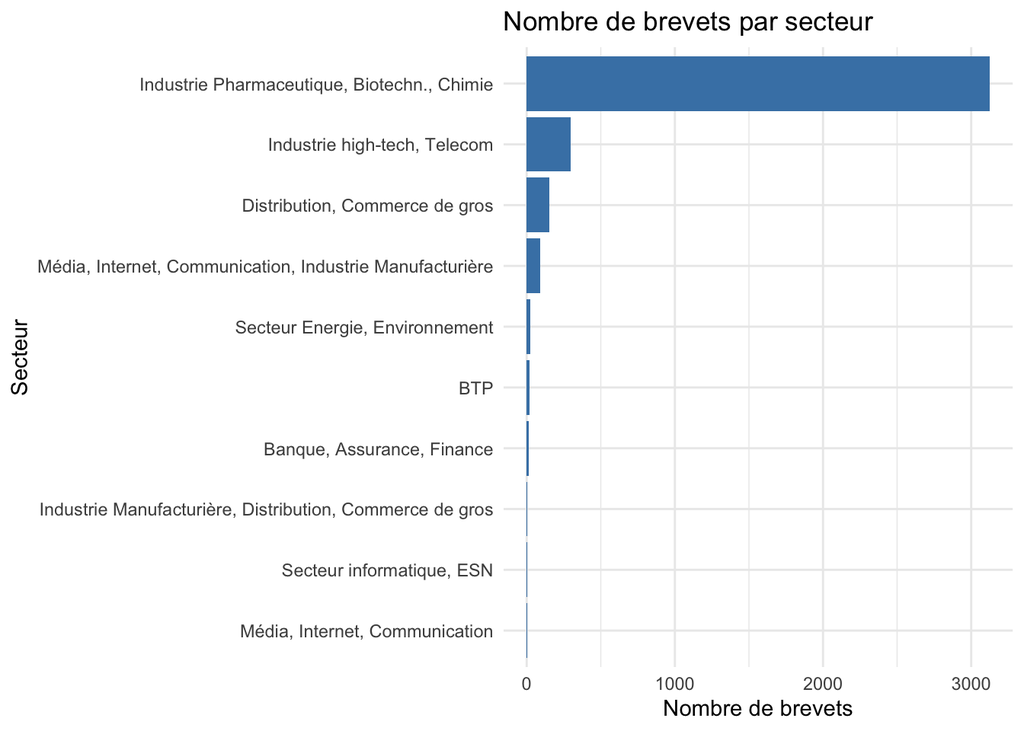

On remarque que l’industrie pharmaceutique, biotechnologie, chimie est à la première place de nouveau. Cela nous confirme que ce secteur domine très largement avec près de 3 000 brevets.  
Cette prédominance peut s’expliquer par l’importance de la recherche et du développement dans la santé, la chimie, et les biotechnologies, où l’innovation est cruciale pour produire de nouveaux médicaments, traitements ou matériaux.  
L’industrie high-tech arrive en deuxième position. De manière cohérente avec notre graphique précédent cela nous confirme l’importance des technologies de pointe et des télécommunications dans le paysage actuel de l’innovation. Les secteurs tels que le BTP, la Banque, l’assurance, la finance, ou encore le secteur informatique, ESN montrent une contribution très marginale en termes de brevets. Cela peut indiquer que dans ces secteurs, l’innovation se traduit moins par des brevets mais plutôt par d’autres formes d’innovation comme des solutions logicielles, des méthodologies ou des services.

### Densité des brevets par département en France

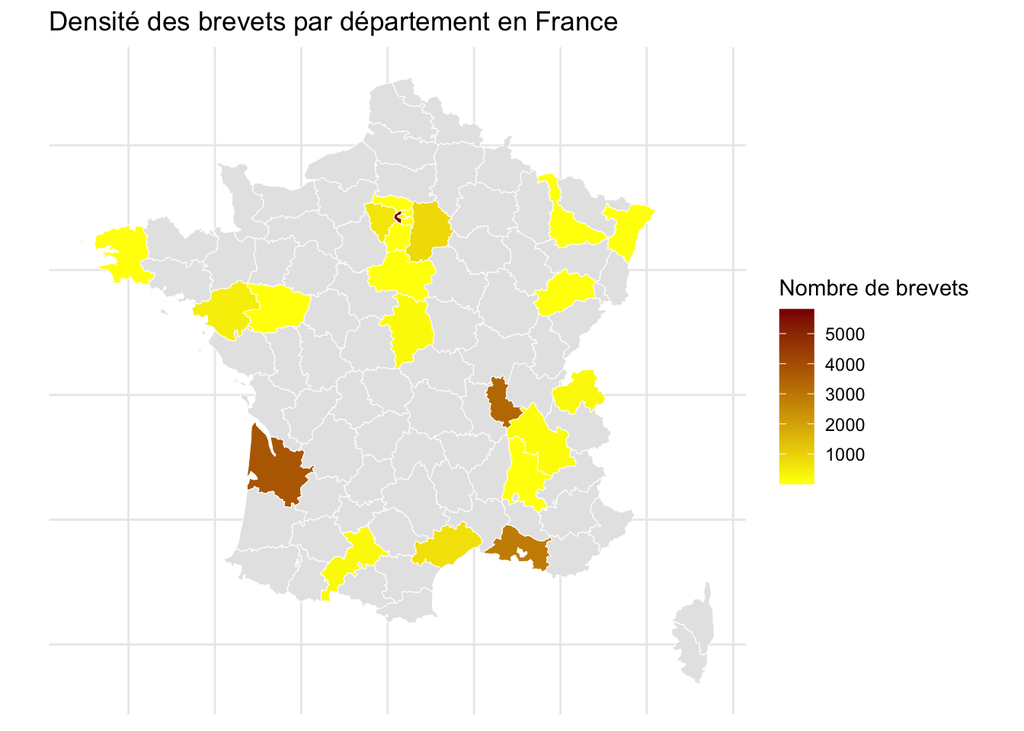

Il existe différent facteurs explicatifs:  
- Les régions innovantes comme l’Île-de-France et la Gironde bénéficient d’une forte présence d’entreprises technologiques, pharmaceutiques et industrielles. Ces départements abritent souvent des centres de R&D, des laboratoires et des grandes entreprises internationales.  
- La proximité des universités et des instituts de recherche favorise la production de brevets, ce qui peut expliquer les départements dynamiques dans des régions comme la région PACA ou Rhône-Alpes.

## Conclusion générale

L’analyse montre une domination des secteurs pharmaceutiques et technologiques dans l’innovation, une concentration géographique marquée dans quelques régions françaises, et une forte demande en compétences techniques et comportementales. Ces résultats soulignent que l’innovation repose sur des pôles stratégiques où les compétences humaines et technologiques se conjuguent pour produire des avancées majeures.